# Evaluación curso R

JAIME JORDÁN LÓPEZ

## Entrega

- Recuerda completar tu **nombre en el apartado author**.
- Además del código, no olvides completar las respuestas a las preguntas indicadas en negrita.
- Si tienes dudas/dificultades, **puedes contactar con los profesores**.
- Deadline: **viernes 10 de junio, 23:59**.
- Puedes realizar la entrega en el mail: **constantino.garciama@ceu.es**.
- La entrega consistirá en este fichero rellenado y el fichero que se genera al hacer `Knit` (un fichero `Rmd` y un fichero `html`).

## Apuestas de adolescentes en UK

El conjunto de datos `teengamb.csv` contiene datos sobre las tasas de juego entre los adolescentes en Gran Bretaña, su género y estatus socioeconómico. Una pregunta que nos puede interesar es cómo se relacionan el género y los ingresos con cuánto juega una persona (céntrate solo en las variables `income`, `sex` y `gamble`)… Sigue los siguientes pasos para crear un ANCOVA…

### 1) Carga y visualiza los datos…

…para valorar si el modelo debe incluir interacciones. Escribe claramente tus conclusiones

```r
library(readr)
teengamb <- read_csv("teengamb.csv")
head(teengamb)
```

```
## # A tibble: 6 × 5
##   sex    status income verbal gamble
##   <chr>   <dbl>  <dbl>  <dbl>  <dbl>
## 1 Female     51   2         8  21.0
## 2 Female     28   2.5       8 -11.1
## 3 Female     37   2         6  -8.59
## 4 Female     28   7         4  17.4
## 5 Female     65   2         8 -17.3
## 6 Female     61   3.47      6  14.9
```

```r
summary(teengamb)
```

```
##      sex                status          income           verbal
##  Length:47          Min.   :18.00   Min.   : 0.600   Min.   : 1.00
##  Class :character   1st Qu.:28.00   1st Qu.: 2.000   1st Qu.: 6.00
##  Mode  :character   Median :43.00   Median : 3.250   Median : 7.00
##                     Mean   :45.23   Mean   : 4.642   Mean   : 6.66
##                     3rd Qu.:61.50   3rd Qu.: 6.210   3rd Qu.: 8.00
##                     Max.   :75.00   Max.   :15.000   Max.   :10.00
##      gamble
##  Min.   :-33.5960
##  1st Qu.: -0.8695
##  Median : 17.7230
##  Mean   : 21.4473
##  3rd Qu.: 35.0519
##  Max.   : 88.4473
```

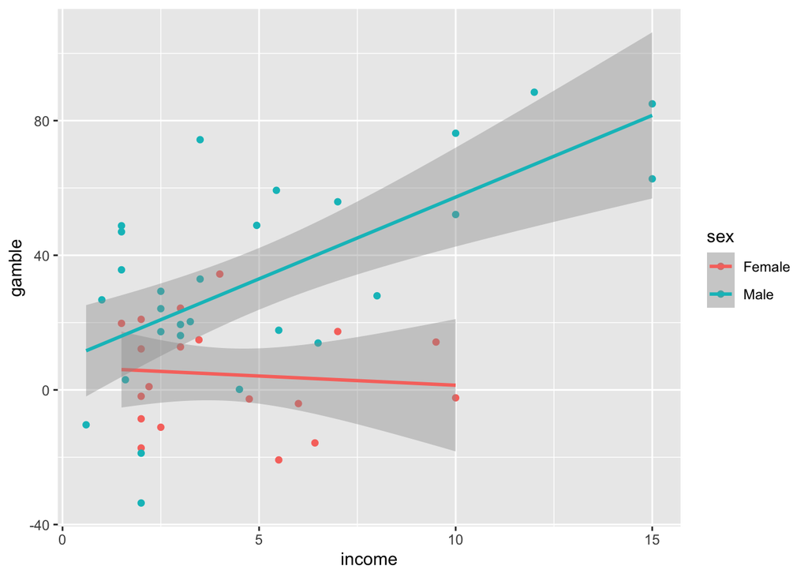

```r
 library(ggplot2)
 library(tidyverse)
ggplot(teengamb, aes(x = income, y = gamble, col = sex)) +
  geom_point() +
  geom_smooth(method="lm")
```

**Conclusiones sobre la necesidad de interacción**:

COMO NO SON PARALELAS LAS LÍNEAS, SÍ QUE HAY INTERACCIÓN

[output not shown]

[output not shown]

```r
teengamb_lm$coefficients
```

```
## (Intercept)      income     sexMale
##  -10.792581    3.708766   25.219019
```

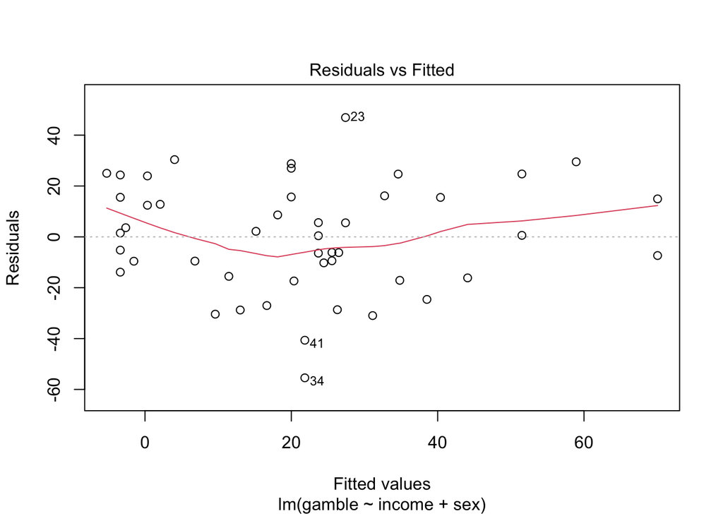

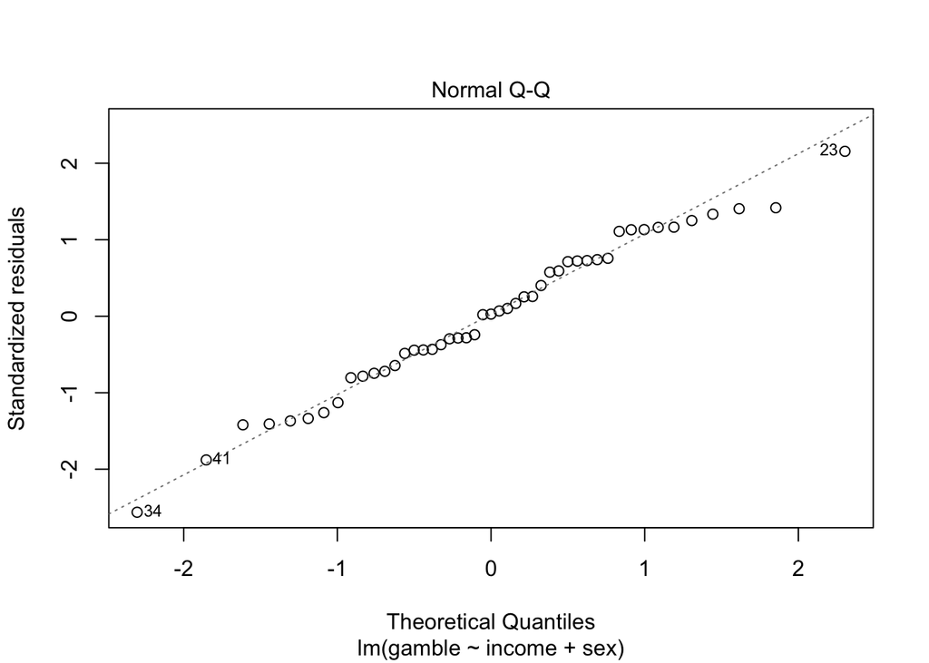

```r
plot(teengamb_lm, which = c(1, 2), ask=FALSE)
```

```r
effectsize(teengamb_lm)
```

```
## # Standardization method: refit
##
## Parameter   | Std. Coef. |         95% CI
## -----------------------------------------
## (Intercept) |      -0.52 | [-0.87, -0.16]
## income      |       0.45 | [ 0.23,  0.68]
## sexMale     |       0.87 | [ 0.41,  1.33]
```

### 3) Interpreta los coeficientes y escribe tus conclusiones.

**Conclusiones sobre las variables de interés**:

### 4) Crea un gráfico con las predicciones de tu modelo…

…y compáralas con los datos reales.

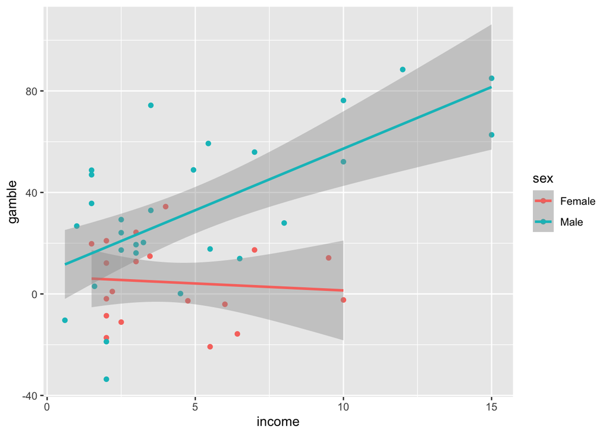

```r
ggplot(teengamb, aes(x = income, y = gamble, col = sex)) +
  geom_point() +
  geom_smooth(method="lm")
```

**¿Es bueno el ajuste?:**

### 5) Valora si las asunciones del modelo se cumplen

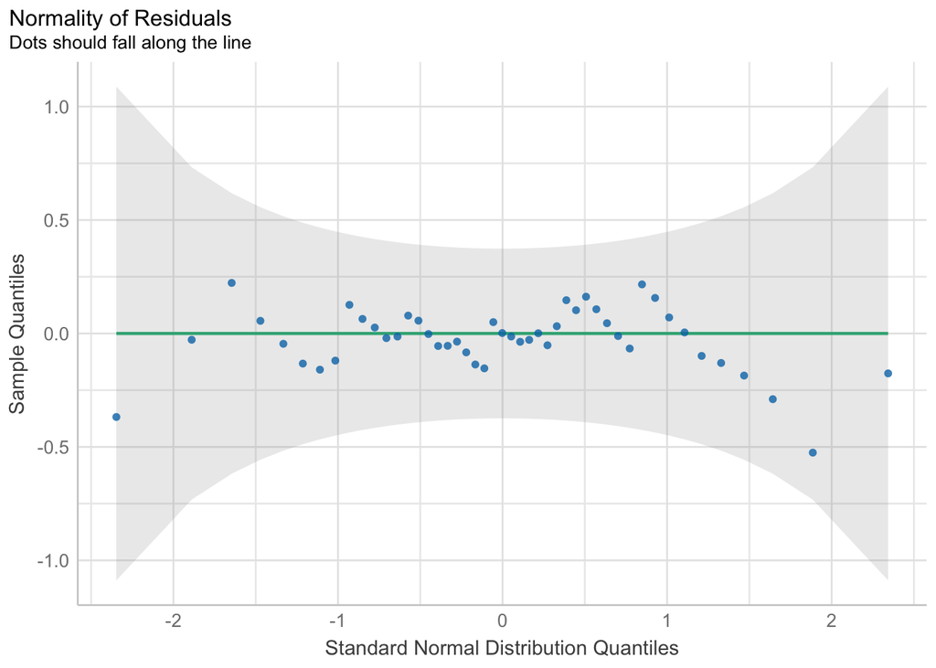

```r
library("performance")
plot(check_normality(teengamb_lm), "qq", detrend = TRUE)
```

**¿Es el modelo correcto?:**